# Exploring Player Strategies in PUBG

Ryan Gosiaco 912819444

```python
import pandas as pd
import numpy as np
from matplotlib import pyplot as plt
```

```python
train_dtypes = {
        'Id'                : 'str',
        'groupId'           : 'str',
        'matchId'           : 'str',
        'assists'           : 'uint8',
        'boosts'            : 'uint8',
        'damageDealt'       : 'float16',
        'DBNOs'             : 'uint8',
        'headshotKills'     : 'uint8',
        'heals'             : 'uint8',
        'killPlace'         : 'uint8',
        'killPoints'        : 'uint8',
        'kills'             : 'uint8',
        'killStreaks'       : 'uint8',
        'longestKill'       : 'float16',
        'matchDuration'     : 'uint8',
        'matchType'         : 'str',
        'maxPlace'          : 'uint8',
        'numGroups'         : 'uint8',
        'rankPoints'        : 'uint8',
        'revives'           : 'uint8',
        'rideDistance'      : 'float16',
        'roadKills'         : 'uint8',
        'swimDistance'      : 'float16',
        'teamKills'         : 'uint8',
        'vehicleDestroys'   : 'uint8',
        'walkDistance'      : 'float16',
        'weaponsAcquired'   : 'uint8',
        'winPoints'         : 'uint8',
        'winPlacePerc'      : 'float16'
}
```

```python
train = pd.read_csv('train_V2.csv', dtype=train_dtypes)
```

```python
train.info()
```

```
<class 'pandas.core.frame.DataFrame'>
RangeIndex: 4446966 entries, 0 to 4446965
Data columns (total 29 columns):
Id                 object
groupId            object
matchId            object
assists            uint8
boosts             uint8
damageDealt        float16
DBNOs              uint8
headshotKills      uint8
heals              uint8
killPlace          uint8
killPoints         uint8
kills              uint8
killStreaks        uint8
longestKill        float16
matchDuration      uint8
matchType          object
maxPlace           uint8
numGroups          uint8
rankPoints         uint8
revives            uint8
rideDistance       float16
roadKills          uint8
swimDistance       float16
teamKills          uint8
vehicleDestroys    uint8
walkDistance       float16
weaponsAcquired    uint8
winPoints          uint8
winPlacePerc       float16
dtypes: float16(6), object(4), uint8(19)
memory usage: 267.2+ MB
```

This dataset contains data from PUBG games, each row is a player and the dataset contains data from various match types like solo, duo, squad, and some other custom game types. I am curious about what features contribute to winning the game and what separates the winners from the losers. (Data downloaded from a Kaggle competition:https://www.kaggle.com/c/pubg-finish-placement-prediction/data)

```python
train.head()
```

|  | Id | groupId | matchId | assists | boosts | damageDealt | DBNOs | headshotKills | heals | killPlace | ... | revives | rideDistance | roadKills | swimDistance | teamKills | vehicleDestroys | walkDistance | weaponsAcquired | winPoints | winPlacePerc |
| --- | --- | --- | --- | --- | --- | --- | --- | --- | --- | --- | --- | --- | --- | --- | --- | --- | --- | --- | --- | --- | --- |
| 0 | 7f96b2f878858a | 4d4b580de459be | a10357fd1a4a91 | 0 | 0 | 0.00000 | 0 | 0 | 0 | 60 | ... | 0 | 0.000000 | 0 | 0.000000 | 0 | 0 | 244.75 | 1 | 186 | 0.444336 |
| 1 | eef90569b9d03c | 684d5656442f9e | aeb375fc57110c | 0 | 0 | 91.50000 | 0 | 0 | 0 | 57 | ... | 0 | 0.004501 | 0 | 11.039062 | 0 | 0 | 1434.00 | 5 | 0 | 0.640137 |
| 2 | 1eaf90ac73de72 | 6a4a42c3245a74 | 110163d8bb94ae | 1 | 0 | 68.00000 | 0 | 0 | 0 | 47 | ... | 0 | 0.000000 | 0 | 0.000000 | 0 | 0 | 161.75 | 2 | 0 | 0.775391 |
| 3 | 4616d365dd2853 | a930a9c79cd721 | f1f1f4ef412d7e | 0 | 0 | 32.90625 | 0 | 0 | 0 | 75 | ... | 0 | 0.000000 | 0 | 0.000000 | 0 | 0 | 202.75 | 3 | 0 | 0.166748 |
| 4 | 315c96c26c9aac | de04010b3458dd | 6dc8ff871e21e6 | 0 | 0 | 100.00000 | 0 | 0 | 0 | 45 | ... | 0 | 0.000000 | 0 | 0.000000 | 0 | 0 | 49.75 | 2 | 0 | 0.187500 |

5 rows × 29 columns

First I split the data into 2 groups, one containing players from solo games, and another containing players from duo games. I mainly focused on solo and duo games because I was short on time. I did not group the duo players together. Also, in a duo match, a team can have up to two people. So a team could have just one player on it.

```python
solo = train[train['matchType'] == 'solo']
duo = train[train['matchType'] == 'duo']
```

```python
#mean number of healing items used
np.mean(solo.heals.values)
```

```
1.012130172636485
```

```python
solo.kills.quantile(0.9)
```

```
3.0
```

```python
#mean number of healing items used
np.mean(duo.heals.values)
```

```
1.338989320484325
```

```python
duo.kills.quantile(0.9)
```

```
3.0
```

3 kills seems oddly low for a player in either a solo or duo game so I decided to look at the counts of the values for kills.

```python
solo['kills'].value_counts()
```

```
0     105651
1      39460
2      17565
3       8647
4       4561
5       2459
6       1412
7        844
8        522
9        312
10       188
11       117
12        75
13        46
14        25
16        15
15        13
17        10
18         7
20         6
19         4
21         4
Name: kills, dtype: int64
```

```python
solo['kills'].mean()
```

```
0.8709321051098421
```

```python
duo['kills'].value_counts()
```

```
0     182295
1      60499
2      34956
3      15903
4       8868
5       4602
6       2674
7       1571
8        912
9        539
10       283
11       204
12       106
13        67
14        45
15        27
16        14
17        12
18         8
19         5
21         1
Name: kills, dtype: int64
```

```python
duo['kills'].mean()
```

```
0.9079661087212324
```

In both solo and duo games, players seem to not get that many kills. This is due to the fact that the dataset includes all player types (ones that join and quit or get disconnected or get killed early on). Also this makes sense because later on we find out that the percentage of winning players is 1.53% for solo and 2.11% for duo games and the percentage of really bad players is 6.22% for solo and 3.99% for duo, so a majority of players rank somewere in between.

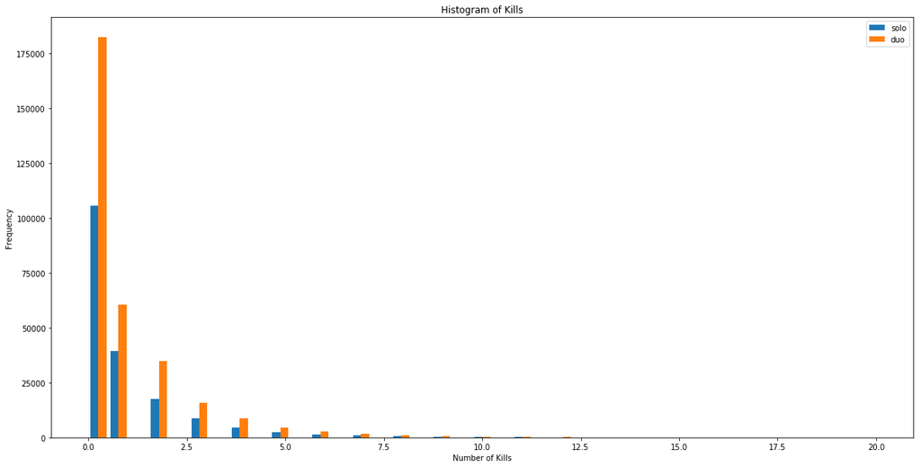

```python
colors = ['solo', 'duo']
plt.figure(figsize=(20,10))
bins = np.linspace(0, 20, 40)
plt.hist([solo['kills'], duo['kills']],bins, label=colors)
plt.legend()
plt.title('Histogram of Kills')
plt.xlabel('Number of Kills')
plt.ylabel('Frequency')
plt.savefig('hist_kills.png')
plt.show()
```

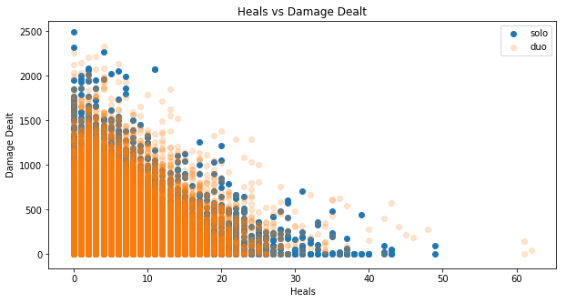

```python
plt.figure()
plt.figure(figsize=(10,5))
plt.scatter(solo['heals'], solo['damageDealt'], label='solo')
plt.scatter(duo['heals'], duo['damageDealt'], label='duo', alpha=0.2)
plt.legend()
plt.title('Heals vs Damage Dealt')
plt.xlabel('Heals')
plt.ylabel('Damage Dealt')
plt.savefig('heal_damage.png')
plt.show()
```

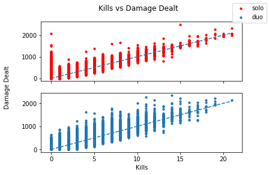

```python
#dashed line assumes 1 kill is 100 damage
plt.figure()
plt.figure(figsize=(20,10))
f, ax = plt.subplots(2, sharex=True)
ax[0].scatter(solo['kills'], solo['damageDealt'], label='solo', color='red', s=10)
x_val = np.arange(0,22,1)
ax[0].plot(x_val, 100*x_val, linestyle='dashed')

ax[1].scatter(duo['kills'], duo['damageDealt'], label='duo', s=10)
ax[1].plot(x_val, 100*x_val, linestyle='dashed')
f.legend()
plt.suptitle('Kills vs Damage Dealt')
plt.xlabel('Kills')
f.text(-0.005,0.5,'Damage Dealt', ha='center', va='center', rotation=90)
plt.savefig('kill_damage.png')
plt.show()
```

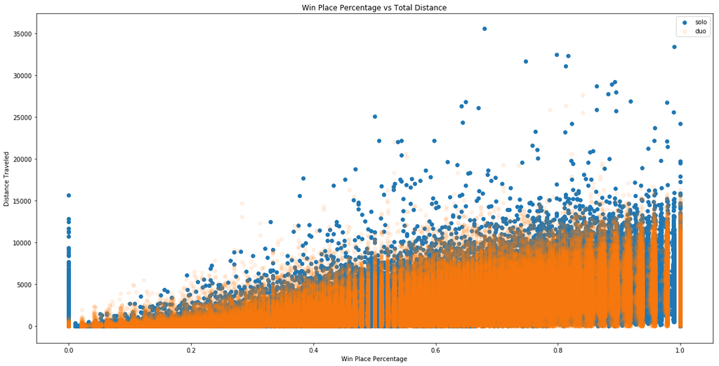

```python
plt.figure()
plt.figure(figsize=(20,10))
#plt.ylim((0.89, 1.01))
plt.scatter(solo['winPlacePerc'], solo['walkDistance'] + solo['rideDistance'] + solo['swimDistance'], label='solo')
plt.scatter(duo['winPlacePerc'], duo['walkDistance'] + duo['rideDistance'] + duo['swimDistance'], label='duo', alpha=0.1)
plt.legend()
plt.title('Win Place Percentage vs Total Distance')
plt.xlabel('Win Place Percentage')
plt.ylabel('Distance Traveled')
plt.savefig('walk_win.png')
plt.show()
```

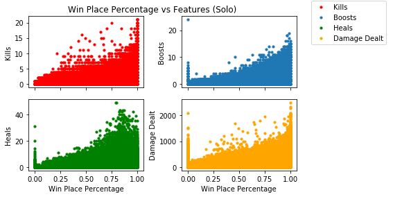

```python
plt.figure()
#plt.figure(figsize=(20,10))
plt.figure(figsize=(80,20))
#plt.ylim((0.89, 1.01))
f, ((ax1,ax2),(ax3,ax4)) = plt.subplots(2,2, sharex='col')

ax1.scatter(solo['winPlacePerc'], solo['kills'], label='Kills', color='red', s=10)
ax1.set_ylabel('Kills')
ax2.scatter(solo['winPlacePerc'], solo['boosts'], label='Boosts', s=10)
ax2.set_ylabel('Boosts')

ax3.scatter(solo['winPlacePerc'], solo['heals'], label='Heals', color='green', s=10)
ax3.set_ylabel('Heals')
ax3.set_xlabel('Win Place Percentage')
ax4.scatter(solo['winPlacePerc'], solo['damageDealt'], label='Damage Dealt', color='orange',s=10)
ax4.set_ylabel('Damage Dealt')
ax4.set_xlabel('Win Place Percentage')

f.tight_layout(pad=0.4, w_pad=0.5, h_pad=1.0, rect=[0,0.03,1,0.95])

f.suptitle('Win Place Percentage vs Features (Solo)')
#f.set_xlabel('Win Place Percentage')
#f.text(-0.005,0.5,'Damage Dealt', ha='center', va='center', rotation=90)
f.legend(bbox_to_anchor=(1.3, 1.0),loc='upper right')
plt.savefig('solo_winper_all_h.png')
plt.show()
```

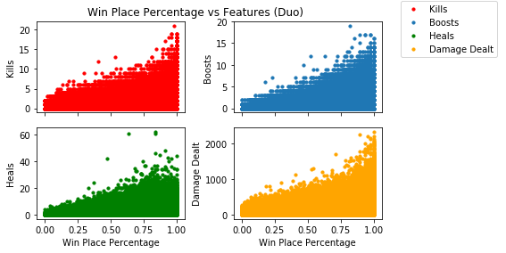

```python
plt.figure()
#plt.figure(figsize=(20,10))
plt.figure(figsize=(80,20))
#plt.ylim((0.89, 1.01))
f, ((ax1,ax2),(ax3,ax4)) = plt.subplots(2,2, sharex='col')

ax1.scatter(duo['winPlacePerc'], duo['kills'], label='Kills', color='red', s=10)
ax1.set_ylabel('Kills')
ax2.scatter(duo['winPlacePerc'], duo['boosts'], label='Boosts', s=10)
ax2.set_ylabel('Boosts')

ax3.scatter(duo['winPlacePerc'], duo['heals'], label='Heals', color='green', s=10)
ax3.set_ylabel('Heals')
ax3.set_xlabel('Win Place Percentage')
ax4.scatter(duo['winPlacePerc'], duo['damageDealt'], label='Damage Dealt', color='orange',s=10)
ax4.set_ylabel('Damage Dealt')
ax4.set_xlabel('Win Place Percentage')

f.tight_layout(pad=0.4, w_pad=0.5, h_pad=1.0, rect=[0,0.03,1,0.95])

f.suptitle('Win Place Percentage vs Features (Duo)')
#f.set_xlabel('Win Place Percentage')
#f.text(-0.005,0.5,'Damage Dealt', ha='center', va='center', rotation=90)
f.legend(bbox_to_anchor=(1.3, 1.0),loc='upper right')
plt.savefig('duo_winper_all.png')
plt.show()
```

At this point I realized these graphs are not very clear with what separates a winning player from a losing player so I decided to go further and separate the winners (players that have a winPlacePerc of 1) and the worst losers (players that have a winPlacePerc of 0)

```python
#first place
solo_w = solo[solo['winPlacePerc'] == 1]
duo_w = duo[duo['winPlacePerc'] == 1]
```

```python
solo.shape
```

```
(181943, 29)
```

```python
solo_w.shape
```

```
(2790, 29)
```

```python
duo.shape
```

```
(313591, 29)
```

```python
duo_w.shape
```

```
(6628, 29)
```

```python
print('Percentage of winners (solo): {:.2f}%'.format(len(solo_w)/len(solo)*100))
print('Percentage of winners (duo): {:.2f}%'.format(len(duo_w)/len(duo)*100))
```

```
Percentage of winners (solo): 1.53%
Percentage of winners (duo): 2.11%
```

```python
#last place
solo_l = solo[solo['winPlacePerc'] == 0.0]
duo_l = duo[duo['winPlacePerc'] == 0.0]
```

```python
solo_l.shape
```

```
(11317, 29)
```

```python
duo_l.shape
```

```
(12510, 29)
```

```python
print('Percentage of worst losers (solo): {:.2f}%'.format(len(solo_l)/len(solo)*100))
print('Percentage of worst losers (duo): {:.2f}%'.format(len(duo_l)/len(duo)*100))
```

```
Percentage of worst losers (solo): 6.22%
Percentage of worst losers (duo): 3.99%
```

The percentage of winners shows that a majority of the dataset are losers. Also, the percentage of the worst losers shows that a majority of players are average. Since winPlacePerc is based off of how many other teams are still alive when they are eliminated (calculated at the end of the game), it does not take into account the possibility of winning but what happened. Due to this, I will now rerun the earlier graphs but from this new perspective.

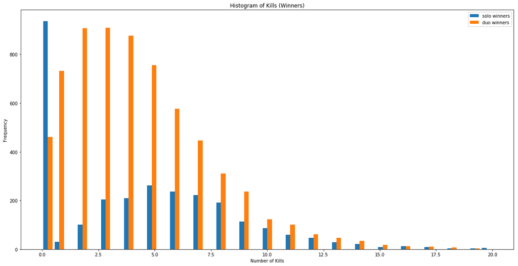

```python
colors = ['solo winners', 'duo winners']
plt.figure(figsize=(20,10))
bins = np.linspace(0, 20, 40)
plt.hist([solo_w['kills'], duo_w['kills']],bins, label=colors)
plt.legend()
plt.title('Histogram of Kills (Winners)')
plt.xlabel('Number of Kills')
plt.ylabel('Frequency')
plt.savefig('hist_kills_winners.png')
plt.show()
```

```python
solo_w.kills.quantile(0.9)
```

```
10.0
```

```python
duo_w.kills.quantile(0.9)
```

```
8.0
```

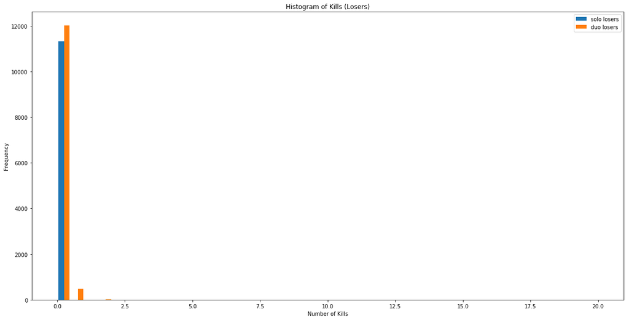

```python
colors = ['solo losers', 'duo losers']
plt.figure(figsize=(20,10))
bins = np.linspace(0, 20, 40)
plt.hist([solo_l['kills'], duo_l['kills']],bins, label=colors)
plt.legend()
plt.title('Histogram of Kills (Losers)')
plt.xlabel('Number of Kills')
plt.ylabel('Frequency')
plt.savefig('hist_kills_losers.png')
plt.show()
```

```python
solo_l.kills.quantile(0.9)
```

```
0.0
```

```python
duo_w.kills.quantile(0.9)
```

```
8.0
```

Unsurprisingly, the worst losers usually get no kills (they die while most if not all of the other players are alive). Also, the distribution of kills for winners is much clearer to see. Interestingly enough, there are still a lot of players in solo games that somehow get 0 kills. I am unsure if the dataset is wrong or if they somehow cheated. In a duo game, a winning player is more likely to have somewhere around 3 to 5 kills while a solo player is more likely to have 5 kills if we ignore the huge spike at 0 kills.

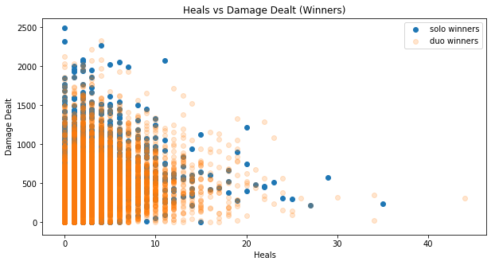

```python
plt.figure()
plt.figure(figsize=(10,5))
plt.scatter(solo_w['heals'], solo_w['damageDealt'], label='solo winners')
plt.scatter(duo_w['heals'], duo_w['damageDealt'], label='duo winners', alpha=0.2)
plt.legend()
plt.title('Heals vs Damage Dealt (Winners)')
plt.xlabel('Heals')
plt.ylabel('Damage Dealt')
plt.savefig('heal_damage_win.png')
plt.show()
```

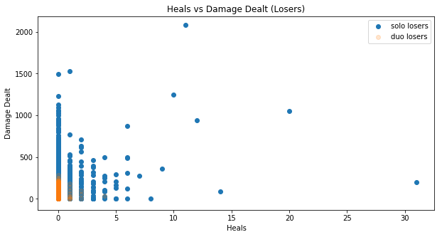

```python
plt.figure()
plt.figure(figsize=(10,5))
plt.scatter(solo_l['heals'], solo_l['damageDealt'], label='solo losers')
plt.scatter(duo_l['heals'], duo_l['damageDealt'], label='duo losers', alpha=0.2)
plt.legend()
plt.title('Heals vs Damage Dealt (Losers)')
plt.xlabel('Heals')
plt.ylabel('Damage Dealt')
plt.savefig('heal_damage_lose.png')
plt.show()
```

Even with the new dataset, the winner graph is not that clear. It does show that most winning players heal somwhere between 0 to 10 times and deal around 0 to 1000 damage. The loser graph shows that some solo players actually do some damage before dying. But there appear to be a few outliers such as a solo player that somehow healed 30 times but still was the first or one of the first to die.

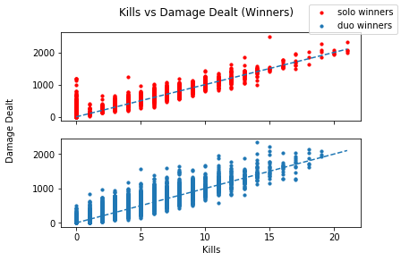

```python
plt.figure()
plt.figure(figsize=(20,10))
f, ax = plt.subplots(2, sharex=True)
ax[0].scatter(solo_w['kills'], solo_w['damageDealt'], label='solo winners', color='red', s=10)
x_val = np.arange(0,22,1)
ax[0].plot(x_val, 100*x_val, linestyle='dashed')

ax[1].scatter(duo_w['kills'], duo_w['damageDealt'], label='duo winners', s=10)
ax[1].plot(x_val, 100*x_val, linestyle='dashed')
f.legend()
plt.suptitle('Kills vs Damage Dealt (Winners)')
plt.xlabel('Kills')
f.text(-0.005,0.5,'Damage Dealt', ha='center', va='center', rotation=90)
plt.savefig('kill_damage_win.png')
plt.show()
```

This graph shows no difference than the previous version. It does not tell us anything about a defining characteristic of a winning player.

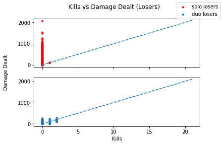

```python
plt.figure()
plt.figure(figsize=(20,10))
f, ax = plt.subplots(2, sharex=True)
ax[0].scatter(solo_l['kills'], solo_l['damageDealt'], label='solo losers', color='red', s=10)
x_val = np.arange(0,22,1)
ax[0].plot(x_val, 100*x_val, linestyle='dashed')

ax[1].scatter(duo_l['kills'], duo_l['damageDealt'], label='duo losers', s=10)
ax[1].plot(x_val, 100*x_val, linestyle='dashed')
f.legend()
plt.suptitle('Kills vs Damage Dealt (Losers)')
plt.xlabel('Kills')
f.text(-0.005,0.5,'Damage Dealt', ha='center', va='center', rotation=90)
plt.savefig('kill_damage_lose.png')
plt.show()
```

This graph is intruiging because it shows that a majority of solo losers actually do damage but get no kills while duo losers may get a couple kills.

After seeing the above graphs, I wanted to explore the variables that contribute the most to the difference between the winners (winPlacePerc == 1) and the worst losers (winPlacePerc == 0). To do this I fit a Random Forest Classifier to a dataset for each solo and duo games with binary labels (winPlacePerc is either 1 or 0). I then got the values for feature importance, the larger the values, the greater the importance.

```python
from sklearn.model_selection import train_test_split

solo_wl = pd.concat([solo_w,solo_l])
duo_wl = pd.concat([duo_w,duo_l])

solo_f = solo_wl.loc[:,solo_wl.columns != 'winPlacePerc']
solo_f = solo_f.loc[:, solo_f.dtypes != object]
solo_y = solo_wl['winPlacePerc']
duo_f = duo_wl.loc[:, duo_wl.columns != 'winPlacePerc']
duo_f = duo_f.loc[:, duo_f.dtypes != object]
duo_y = duo_wl['winPlacePerc']

sx_train, sx_test, sy_train, sy_test = train_test_split(solo_f, solo_y, test_size=0.33, random_state=0)
dx_train, dx_test, dy_train, dy_test = train_test_split(duo_f, duo_y, test_size=0.33, random_state=0)
```

```python
## Import the random forest model.
from sklearn.ensemble import RandomForestClassifier

srf = RandomForestClassifier(n_estimators=100)
#Fit the model
srf.fit(sx_train, sy_train)
#score it on testing data.
srf.score(sx_test, sy_test)
```

```
0.9705756013745704
```

```python
solo_f_import = pd.DataFrame(srf.feature_importances_,index = sx_train.columns,columns=['importance']).sort_values('importance',ascending=False)
```

```python
solo_f_import
```

|  | importance |
| --- | --- |
| killPlace | 2.435236e-01 |
| longestKill | 1.319044e-01 |
| killStreaks | 1.041559e-01 |
| walkDistance | 8.898272e-02 |
| boosts | 8.438799e-02 |
| kills | 7.336871e-02 |
| damageDealt | 7.078818e-02 |
| weaponsAcquired | 4.501957e-02 |
| heals | 3.653444e-02 |
| maxPlace | 2.724501e-02 |
| rideDistance | 2.364994e-02 |
| headshotKills | 2.357564e-02 |
| numGroups | 2.068610e-02 |
| matchDuration | 1.751059e-02 |
| assists | 4.099496e-03 |
| swimDistance | 3.210625e-03 |
| rankPoints | 1.061009e-03 |
| winPoints | 2.225362e-04 |
| killPoints | 7.307063e-05 |
| teamKills | 4.357016e-07 |
| revives | 0.000000e+00 |
| roadKills | 0.000000e+00 |
| vehicleDestroys | 0.000000e+00 |
| DBNOs | 0.000000e+00 |

```python
## Import the random forest model.
from sklearn.ensemble import RandomForestClassifier

drf = RandomForestClassifier(n_estimators=100)
#Fit the model
drf.fit(dx_train, dy_train)
#score it on testing data.
drf.score(dx_test, dy_test)
```

```
0.9987333755541482
```

```python
duo_f_import = pd.DataFrame(drf.feature_importances_,index = dx_train.columns,columns=['importance']).sort_values('importance',ascending=False)
```

```python
duo_f_import
```

|  | importance |
| --- | --- |
| boosts | 0.233656 |
| walkDistance | 0.152477 |
| killPlace | 0.145140 |
| weaponsAcquired | 0.112036 |
| longestKill | 0.082552 |
| heals | 0.061837 |
| damageDealt | 0.059639 |
| kills | 0.031051 |
| assists | 0.028011 |
| killStreaks | 0.027495 |
| DBNOs | 0.023273 |
| headshotKills | 0.018659 |
| rideDistance | 0.011337 |
| revives | 0.008260 |
| swimDistance | 0.001225 |
| maxPlace | 0.000905 |
| rankPoints | 0.000643 |
| numGroups | 0.000635 |
| matchDuration | 0.000540 |
| killPoints | 0.000328 |
| winPoints | 0.000287 |
| teamKills | 0.000009 |
| vehicleDestroys | 0.000002 |
| roadKills | 0.000000 |

For solo games, the top 5 features of greatest importance to winPlacePerc are killPlace, longestKill, killStreaks, walkDistance, and boosts. For duo games, the top 5 features of greatest importance to winPlacePerc are boosts, walkDistance, killPlace, weaponsAquired, and longestKill. While these shed some light on what differentiates a good player from a bad player, it does not show the difference between a good player and an average player since winPlacePerc is continuous it is difficult to assign labels for the Random Forest Classifier to work. I believe there are other methods to explore feature importance but I did not have enough time to explore them.

With what I have so far, I believe that for solo games, skill based features such as killPlace (Ranking in match of number of enemy players killed.), longestKill (Longest distance between player and player killed at time of death. This may be misleading, as downing a player and driving away may lead to a large longestKill stat.), killStreaks (Max number of enemy players killed in a short amount of time.), and boosts (Number of boost items used.) are the most important in separating good players from bad players. This is more apparent in solo games because you are in a one versus all situation where your raw skill has to prevail to win the overall match.

For duo games however, it appears that looting (picking up items and weapons) contributes heavily to the difference between winning and dying early. Also, skill based features like killPlace, and longestKill are still important.